# Relationship of some selected Prosper Loan variables

## by Ismail Adamu

## Investigation Overview

> For this presentation, I concentrate solely on the impact of income range on loan status, as well as the impact of loan term on monthly payment and loan amount.

## Dataset Overview

> The data set contains 113,937 loans, each with 81 variables including loan amount, borrower rate (or interest rate), current loan status, borrower income, among others.

## Distribution of Income Range

> The two income brackets with the greatest number of borrowers are 25k-49k and 50k-74k; they both have nearly the same numbers of borrowers. The number of borrowers with incomes between 75k and 99k and 100,000k+ is nearly equal.

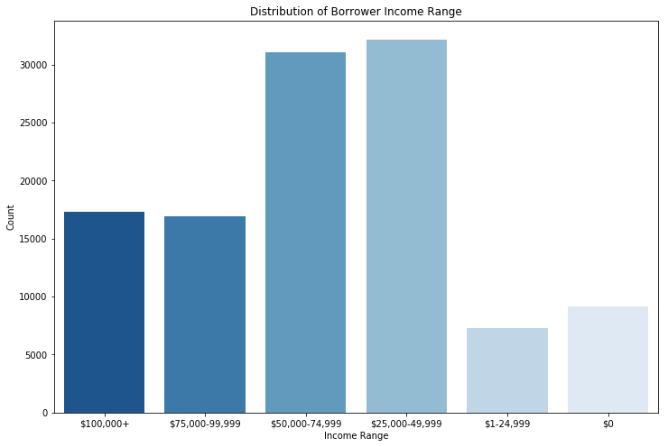

## Distribution of Loan Status

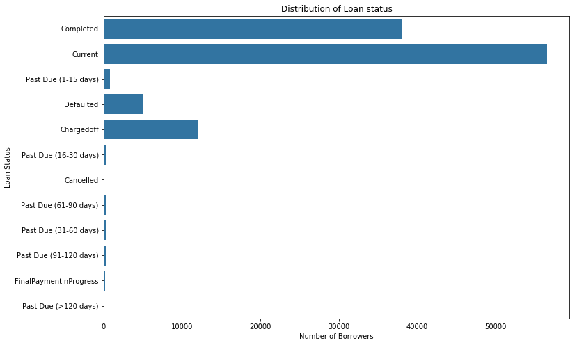

## Relationship between Income Range and Loan Status

> Although people with incomes of 0 dollar tend to default more frequently, it is surprising to see that the number of completed loans for income ranges of atleast 100,000 dollars and 75k-99k dollars is lower than 0 dollar. This suggests that the income range is unimportant for repaying a loan. The lowest completed loans belong to borrowers with incomes between 1 dollar and 25,000 dollars. For all income levels, the likelihood of a loan cancellation is typically very low.

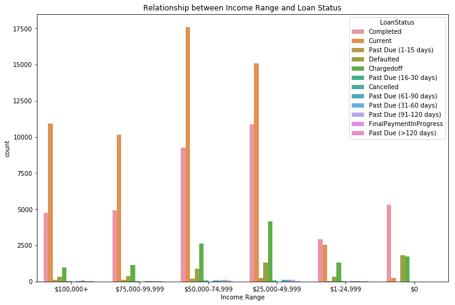

## Relationship between Monthly payment, Loan amount and Term

> This multivariate plot helps us better understand the multiple positive correlation between the Monthly Payment and Loan Amount. The amount of the monthly payment is significantly influenced by the loan's term. We can see that loans with terms of at least 60 months have the lowest monthly payments and those with terms of at least 12 months have the highest monthly payments. It is safe to assume that the monthly payment will be lower with a longer loan term.

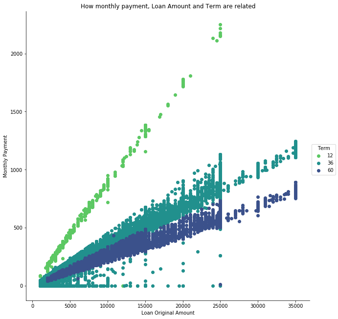